# Gene Activity Score

```r
## Load libraries


suppressPackageStartupMessages({
library(ArchR)
library(rhdf5)
library(tidyverse)
library(reticulate)
library(zellkonverter)
#library(caret)
h5disableFileLocking()})
```

```r
# load ArchR project
proj <- loadArchRProject(path = "04_peak_calling_ArchRobject/")
```

# Computing gene activity scores from Peak2Gene Links

The following function is based on the function used in Cicero to compute gene activity scores from co-accessibility scores of sites linked to each gene k. For more information on how the calculation is implemented in Cicero see here: https://www.sciencedirect.com/science/article/pii/S1097276518305471?via%3Dihub#sec4

## Implementation for peak-to-gene linkage matrix

The main idea is to adapt the function which is used to determine gene activity scores based on co-accessibility scores (scATAC-seq data only, no scRNA-seq data) to our case. For our case we want it to work for peak-to-gene links. Here we do not want to differentiate between proximal and distal sites of a gene, but simply use all peaks which are correlated with our gene k.

To create peak-to-gene links, cell aggregates were created and the peak regions were correlated with the gene regions across all cells.

Below you can see the peak-to-gene linkage dataframe.

```r
p2g <- getPeak2GeneLinks(
  ArchRProj = proj,
  corCutOff = -1,
  resolution = 1,
  FDRCutOff = 1e-04,
  varCutOffATAC = .25,
  varCutOffRNA = .25,
  returnLoops = FALSE
)

print(paste0("Number of peak2gene links found: ", dim(p2g)))
```

[1] “Number of peak2gene links found: 758893” [2] “Number of peak2gene links found: 6”

```r
print(paste0("Total number of peaks called in the dataset: ", length(metadata(p2g)$peakSet)))
```

[1] “Total number of peaks called in the dataset: 512953”

```r
print(paste0("For each of the peaks we have metadata containing information on peakType, nearestGene, disttoGeneStart,etc..."))
```

[1] “For each of the peaks we have metadata containing information on peakType, nearestGene, disttoGeneStart,etc…”

```r
p2g %>% head %>% knitr::kable()
```

| idxATAC | idxRNA | Correlation | FDR | VarQATAC | VarQRNA |
| --- | --- | --- | --- | --- | --- |
| 4 | 1 | 0.4447460 | 0 | 0.7037604 | 0.9725228 |
| 6 | 1 | -0.3366633 | 0 | 0.8375309 | 0.9725228 |
| 7 | 1 | -0.2650031 | 0 | 0.3021349 | 0.9725228 |
| 8 | 1 | -0.2893693 | 0 | 0.6282291 | 0.9725228 |
| 9 | 1 | 0.7472881 | 0 | 0.7915209 | 0.9725228 |
| 10 | 1 | -0.3152997 | 0 | 0.8777783 | 0.9725228 |

```r
# read in ATAC metadata created by ArchR
seATAC <- readRDS("/omics/groups/OE0533/internal/katharina/scDoRI/gastrulation_data/03_added_gene_expression_ArchRobject/Peak2GeneLinks/seATAC-Group-KNN.rds")

#read in RNA metadata created by ArchR
RNA_meta <- readRDS("/omics/groups/OE0533/internal/katharina/scDoRI/gastrulation_data/03_added_gene_expression_ArchRobject/Peak2GeneLinks/seRNA-Group-KNN.rds")
```

First, we will create a sparse matrix for the peak2gene links from the dataframe shown above.

This is our correlation matrix $U \in{\mathbb{R}^{KxJ}}$ with $K$ being the total number of genes and $J$ being the total number of peaks. Each entry $U_{kj}$ corresponds to the correlation value between peak $j$ and gene $k$ across all cell aggregates.

ToDo: Is peak matrix binary? Should it be binary?

```r
# the peak matrix contains idx numbers as rows -> we can link these to peak coordinates
# and cellnames as columns

# extract peak SE from the project
peakset <- getMatrixFromProject(proj, useMatrix = "PeakMatrix", binarize = TRUE)

# get matrix
peak_mat <- assays(peakset)[[1]]

# use index to asssign rownames to the matrix
rownames(peak_mat) <- rowData(peakset)$idx


# extract gene expression SE from the project
gene_expression <- getMatrixFromProject(proj, useMatrix = "GeneExpressionMatrix")

print(paste0("The peak matrix has dimensions: ", dim(peak_mat)[[1]], " peaks and ", dim(peak_mat)[[2]], "cells"))
```

```
## [1] "The peak matrix has dimensions: 512953 peaks and 28154cells"
```

```r
print(paste0("The gene expression matrix contains ", dim(gene_expression) [[1]], " genes"))
```

```
## [1] "The gene expression matrix contains 22273 genes"
```

```r
# create column and row indices for the unique peak and rna indices
p2g$ColIndex <- match(p2g$idxATAC, unique(p2g$idxATAC))
p2g$RowIndex <- match(p2g$idxRNA, unique(p2g$idxRNA))

# create a sparse matrix with the correlation values
p2g_mat <- sparseMatrix(i = p2g$RowIndex,
                        j = p2g$ColIndex,
                        x = p2g$Correlation,
                        dims = c(length(unique(p2g$idxRNA)),
                                 length(unique(p2g$idxATAC))),
                        dimnames = list(unique(p2g$idxRNA),
                                        unique(p2g$idxATAC)))

print(paste0("The sparse matrix of correlations has dimensions: ", dim(p2g_mat)[[1]], " genes and ", dim(p2g_mat)[[2]], " peaks."))
```

```
## [1] "The sparse matrix of correlations has dimensions: 16418 genes and 260052 peaks."
```

Now we will calculate a weighted sum of accessible peaks in a cell. The weights are the corresponding correlation values between a particular peak $j$ and gene $k$. $A\in\mathbb{R}^{JxI}$ is the binary peak accessibility matrix with $A_{ji} = 1$ if peak $j$ is found in cell $i$ and $A_{ji} = 0$ otherwise.

$R_{ki} = \sum_{U_{kj}A_{ji}}$, where $R_{ki}$ corresponds to the gene activity score of gene $k$ in cell $i$.

$R = U I$ with $R \in \mathbb{R}^{KxI}$.

Below you can see the first few entries of this gene activity score matrix. Note that some entries are negative.

```r
# we subset the accessibility matrix to contain only peaks which are also
# included in our p2g matrix
peak_mat_subset <- peak_mat[as.integer(colnames(p2g_mat)), ]

# Now we can compute a weighted sum of peak2gene correlations for each
# peak and gene
corr_sum <- p2g_mat %*% peak_mat_subset
print(corr_sum[1:5, 1:5])
## 5 x 5 sparse Matrix of class "dgCMatrix"
##   E8.5_rep1#GTGGATGCACTAGCGT-1 E8.5_rep1#GAGCTGCTCATTGACA-1
## 1                    0.3818307                    .
## 2                    .                            .
## 3                    2.3159641                    2.4541047
## 4                    1.1147615                   -0.8421051
## 5                    2.5996962                    1.7255112
##   E8.5_rep1#AAGCGCTGTTATCCTA-1 E8.5_rep1#CTTGACGAGTTCCCGT-1
## 1                    .                            .
## 2                    .                            .
## 3                    0.7728631                    0.4423486
## 4                    2.1916584                    1.2354897
## 5                    2.4161846                    0.8874068
##   E8.5_rep1#AAGCGCTGTTCCTGTG-1
## 1                    .
## 2                    .
## 3                    1.3806131
## 4                    0.8678879
## 5                    1.5920868
```

### Linear regression to account for differences in library size.

The aggregate correlation values will depend on scATAC-seq library depth in each cell. We can capture this relationship with a linear regression.

$\log{\sum_{k}{r_k} = \beta_0 + \beta_A \log(\sum_j{A_{ji}})}$

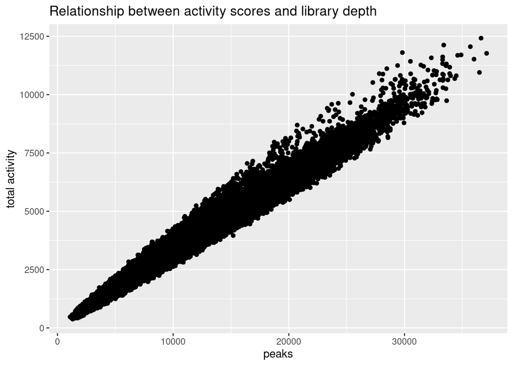

```r
# lets create a copy of the matrix
scores <- corr_sum

# create a dataframe for computing the linear model
normalization_df <- data.frame(cell = colnames(scores),
                               total_activity = colSums(scores),
                               total_sites = colSums(peak_mat_subset))

#plot the relationship between library depth and activity scores
normalization_df %>% ggplot(aes(x = total_sites, y = total_activity)) + geom_point() +
  labs(title = "Relationship between activity scores and library depth",
       y = "total activity", x = "peaks")
```

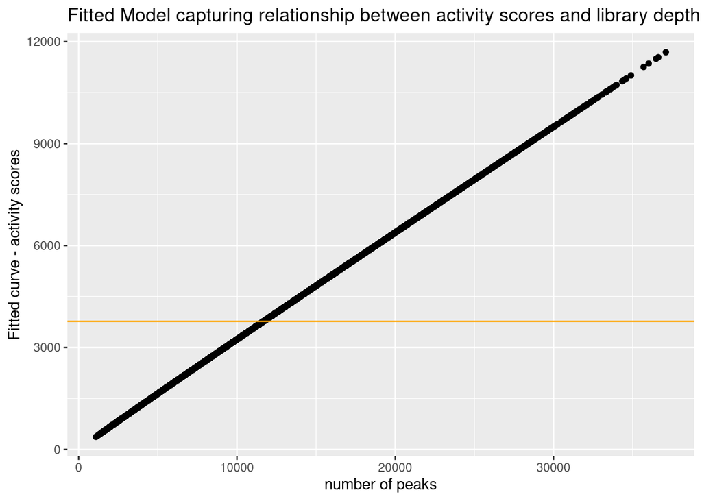

```r
# compute a linear model
activity_model <- stats::lm(log(total_activity) ~ log(total_sites),
                            data = normalization_df)

# extract the fitted model
normalization_df$fitted_curve <- exp(as.vector(predict(activity_model, type = "response")))

# plot the fitted model
normalization_df %>% ggplot(aes(x = total_sites, y = fitted_curve)) + geom_point() +
  labs(title = "Fitted Model capturing relationship between activity scores and library depth", y = "Fitted curve - activity scores", x = "number of peaks") +
  geom_hline(yintercept = mean(normalization_df$fitted_curve), color = "orange")
```

```r
print(paste0("Mean fitted activity: ", mean(normalization_df$fitted_curve)))
```

```
## [1] "Mean fitted activity: 3768.75967739201"
```

### SizeFactors

The output of the linear model is used to scale the accessibility we computed above.

$\tilde{R}_{ki}= R_{ki} * \frac{\sum_{i}{r_i}}{r_i}$

If an activity score $R_{ki}$ for a given cell $i$ is smaller than the average activity score, the size factor will be >1 and if the activity score is bigger than the average activity score the size factor will be <1. After correcting with the size factors we would expect the linear increase in activity with increasing number of accessibile sites to be corrected for.

In the plot below we can see that we have corrected for this linear relationship.

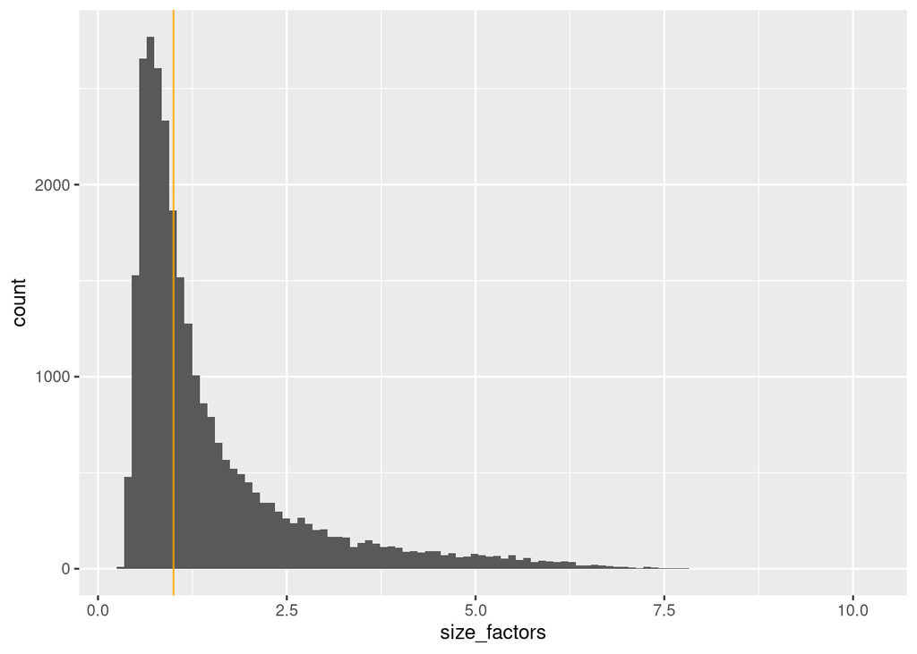

```r
# each cell is scaled by a factor corresponding to its library depth
#size_factors <- log(normalization_df$fitted_curve) / mean(log(normalization_df$fitted_curve))
#size_factors <- log(sum(normalization_df$fitted_curve)) / log(normalization_df$fitted_curve)

size_factors <- mean(normalization_df$fitted_curve) / normalization_df$fitted_curve


ggplot(as.data.frame(size_factors), aes(x = size_factors)) +
  geom_histogram(bins = 100) +
  geom_vline(xintercept = 1, color="orange", alpha=0.8)
```

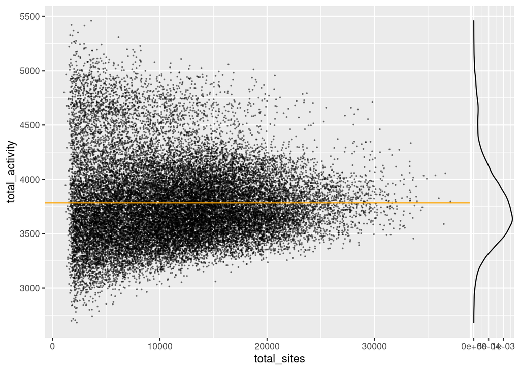

```r
#size_factors_mat <- Matrix::Diagonal(x = 1/size_factors)
size_factors_mat <- Matrix::Diagonal(x = size_factors)

row.names(size_factors_mat) <- normalization_df$cell
size_factors_mat[1:5, 1:5]
## 5 x 5 diagonal matrix of class "ddiMatrix"
##                              [,1]      [,2]      [,3]      [,4]      [,5]
## E8.5_rep1#GTGGATGCACTAGCGT-1 0.3319023         .         .         .         .
## E8.5_rep1#GAGCTGCTCATTGACA-1         . 0.3825948         .         .         .
## E8.5_rep1#AAGCGCTGTTATCCTA-1         .         . 0.3766856         .         .
## E8.5_rep1#CTTGACGAGTTCCCGT-1         .         .         . 0.3794099         .
## E8.5_rep1#AAGCGCTGTTCCTGTG-1         .         .         .         . 0.3765924
# adjust scores by size factors
new_scores <- Matrix::t(size_factors_mat %*% Matrix::t(scores))
print(new_scores[1:5, 1:5])
## 5 x 5 sparse Matrix of class "dgCMatrix"
##   E8.5_rep1#GTGGATGCACTAGCGT-1 E8.5_rep1#GAGCTGCTCATTGACA-1
## 1                    0.1267305                    .
## 2                    .                            .
## 3                    0.7686739                    0.9389277
## 4                    0.3699919                   -0.3221850
## 5                    0.8628452                    0.6601716
##   E8.5_rep1#AAGCGCTGTTATCCTA-1 E8.5_rep1#CTTGACGAGTTCCCGT-1
## 1                    .                            .
## 2                    .                            .
## 3                    0.2911264                    0.1678314
## 4                    0.8255662                    0.4687570
## 5                    0.9101420                    0.3366909
##   E8.5_rep1#AAGCGCTGTTCCTGTG-1
## 1                    .
## 2                    .
## 3                    0.5199284
## 4                    0.3268400
## 5                    0.5995678

# plot the total sites vs total activities after correction
df <- data.frame(cell = colnames(new_scores),
                               total_activity = colSums(new_scores),
                               total_sites = colSums(peak_mat_subset))
df %>% ggplot(aes(x = total_sites, y = total_activity)) +
  geom_point(size=0.2, alpha=0.4) +
  ggside::geom_ysidedensity() +
  geom_hline(yintercept = mean(df$total_activity), color = "orange")
```

```r
print(paste0("Mean activity after correction (expected to be the same as the mean of the fitted activity: ", mean(df$total_activity)))
```

```
## [1] "Mean activity after correction (expected to be the same as the mean of the fitted activity: 3785.86852956847"
```

```r
min(new_scores)
```

```
## [1] -36.35994
```

```r
max(new_scores)
```

```
## [1] 61.6432
```

```r
colSums(new_scores) %>% head
## E8.5_rep1#GTGGATGCACTAGCGT-1 E8.5_rep1#GAGCTGCTCATTGACA-1
##                     3823.686                     3804.544
## E8.5_rep1#AAGCGCTGTTATCCTA-1 E8.5_rep1#CTTGACGAGTTCCCGT-1
##                     3784.166                     4276.029
## E8.5_rep1#AAGCGCTGTTCCTGTG-1 E8.5_rep1#GTGCTTCTCATGAAGG-1
##                     4222.736                     3800.581
```

### Transform

Then we exponentiate the values, because the RNA-seq measures are typically log-normally distributed. To create relative exponentiated gene accessibility values, we scale them by the total exponentiated gene accesibility values. We get our gene activity scores $G_{ki}$.

Because for log transformation of gene expression counts we add a pseudocount, we need to subtract one here:

$e^{\tilde{R}} - 1$

$G_{ki} = \frac{e^{\tilde{R}_{ki}}-1}{\sum_k{e^{\tilde{R}_{ki}}-1}}$

Below you can see the first few entries of the exponentiated values, before scaling.

```r
# plot the total sites vs total activities after correction
# this will set an upper bound to 1e9
new_scores@x <- pmin(1e9, exp(new_scores@x) - 1)
print(new_scores[1:5, 1:5])
## 5 x 5 sparse Matrix of class "dgCMatrix"
##   E8.5_rep1#GTGGATGCACTAGCGT-1 E8.5_rep1#GAGCTGCTCATTGACA-1
## 1                    0.1351111                    .
## 2                    .                            .
## 3                    1.1569040                    1.5572378
## 4                    0.4477229                   -0.2754359
## 5                    1.3698940                    0.9351244
##   E8.5_rep1#AAGCGCTGTTATCCTA-1 E8.5_rep1#CTTGACGAGTTCCCGT-1
## 1                    .                            .
## 2                    .                            .
## 3                    0.3379337                    0.1827372
## 4                    1.2831732                    0.5980066
## 5                    1.4846753                    0.4003062
##   E8.5_rep1#AAGCGCTGTTCCTGTG-1
## 1                    .
## 2                    .
## 3                    0.6819072
## 4                    0.3865796
## 5                    0.8213314
```

```r
min(new_scores)
```

```
## [1] -1
```

```r
max(new_scores)
```

```
## [1] 1e+09
```

```r
colSums(new_scores) %>% head
## E8.5_rep1#GTGGATGCACTAGCGT-1 E8.5_rep1#GAGCTGCTCATTGACA-1
##                     19131.30                     62371.82
## E8.5_rep1#AAGCGCTGTTATCCTA-1 E8.5_rep1#CTTGACGAGTTCCCGT-1
##                     31585.15                  14061170.66
## E8.5_rep1#AAGCGCTGTTCCTGTG-1 E8.5_rep1#GTGCTTCTCATGAAGG-1
##                 191131847.90                     15074.90
```

Here, you can see the first few entries of the transformed matrix. The column sum is now 1.

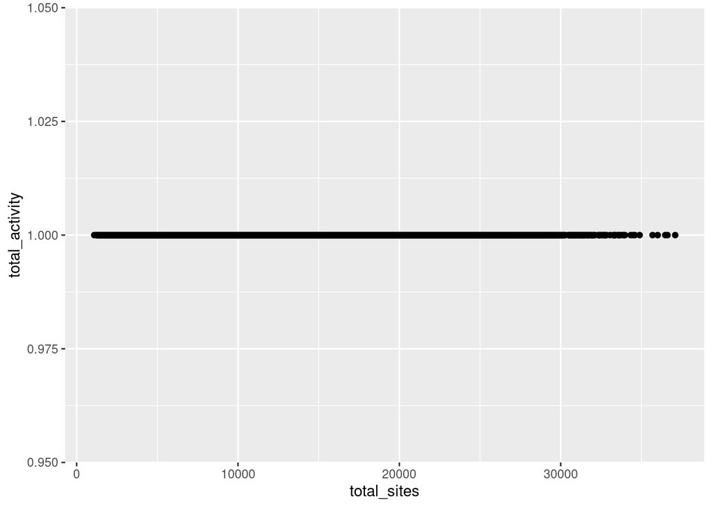

```r
# scale with total activity scores again
scale_factors <- Matrix::Diagonal(x = 1/Matrix::colSums(new_scores))

new_scores <- Matrix::t(scale_factors %*% Matrix::t(new_scores))
print(new_scores[1:5, 1:5])
## 5 x 5 sparse Matrix of class "dgCMatrix"
##   E8.5_rep1#GTGGATGCACTAGCGT-1 E8.5_rep1#GAGCTGCTCATTGACA-1
## 1                 7.062303e-06                 .
## 2                 .                            .
## 3                 6.047178e-05                 2.496701e-05
## 4                 2.340263e-05                -4.416031e-06
## 5                 7.160484e-05                 1.499274e-05
##   E8.5_rep1#AAGCGCTGTTATCCTA-1 E8.5_rep1#CTTGACGAGTTCCCGT-1
## 1                 .                            .
## 2                 .                            .
## 3                 1.069913e-05                 1.299587e-08
## 4                 4.062584e-05                 4.252894e-08
## 5                 4.700549e-05                 2.846891e-08
##   E8.5_rep1#AAGCGCTGTTCCTGTG-1
## 1                 .
## 2                 .
## 3                 3.567732e-09
## 4                 2.022581e-09
## 5                 4.297198e-09

# Check whether the column sum is 1:
colSums(new_scores)%>% head
## E8.5_rep1#GTGGATGCACTAGCGT-1 E8.5_rep1#GAGCTGCTCATTGACA-1
##                            1                            1
## E8.5_rep1#AAGCGCTGTTATCCTA-1 E8.5_rep1#CTTGACGAGTTCCCGT-1
##                            1                            1
## E8.5_rep1#AAGCGCTGTTCCTGTG-1 E8.5_rep1#GTGCTTCTCATGAAGG-1
##                            1                            1


# plot the total sites vs total activities after correction
corrected_df <- data.frame(cell = colnames(corr_sum),
                               total_activity = colSums(new_scores),
                               total_sites = colSums(peak_mat_subset))
corrected_df %>% ggplot(aes(x = total_sites, y = total_activity)) + geom_point()
```

```r
print(paste0("The maximum value is: ", min(new_scores)))
```

[output not shown]

```r
print(paste0("The minimum value is: ", max(new_scores)))
```

[output not shown]

```r
gene_attr <- tibble::tibble(
  gene = rownames(new_scores),
  mean = Matrix::rowMeans(new_scores),
  detection_rate = Matrix::rowMeans(new_scores > 0),
  var = MatrixGenerics::rowVars(new_scores)) %>%
  mutate(log10_mean = log10(mean),
         log10_var = log10(var))
```

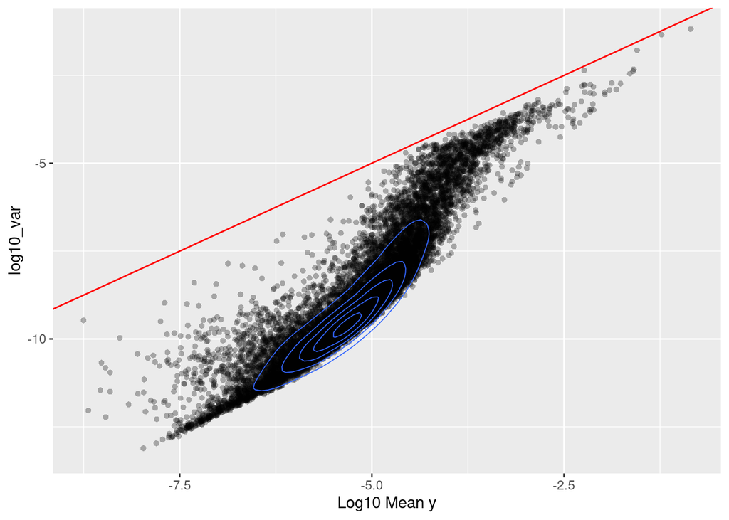

```r
ggplot(gene_attr, aes(log10_mean, log10_var)) +
  geom_point(alpha = 0.3, shape = 16) +
  geom_density_2d(size = 0.3, bins = 6) +
  geom_abline(intercept = 0, slope = 1, color = "red") +
  labs(x = "Log10 Mean y", "Log10 Var y")
```

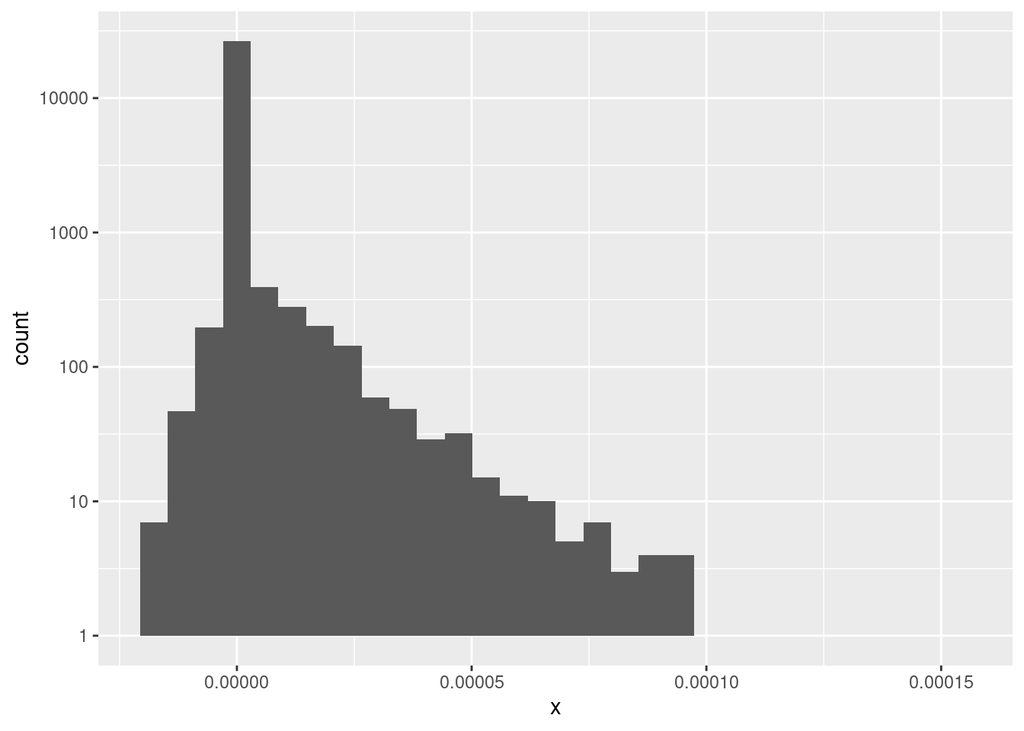

```r
data.frame(x = new_scores[1,]) %>% ggplot(aes(x = x)) + geom_histogram() +
  scale_y_log10()
```

Same for gene expression:

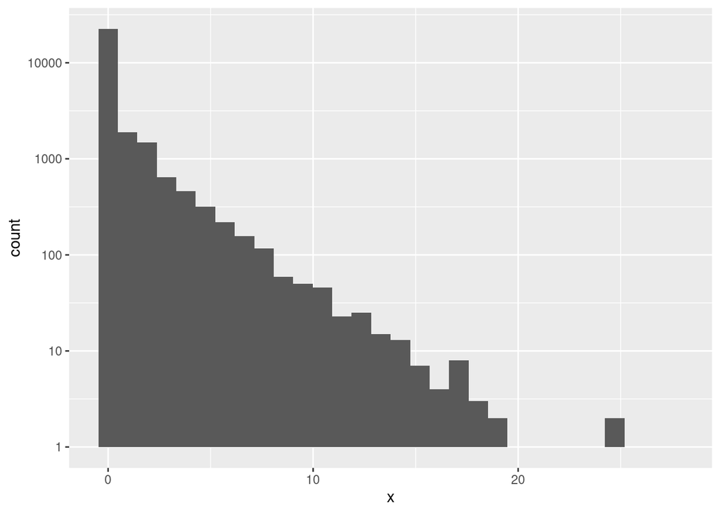

```r
gene_expression_mat <- assays(gene_expression)[[1]]
data.frame(x = gene_expression_mat[1,]) %>% ggplot(aes(x = x)) + geom_histogram() +
  scale_y_log10()
```

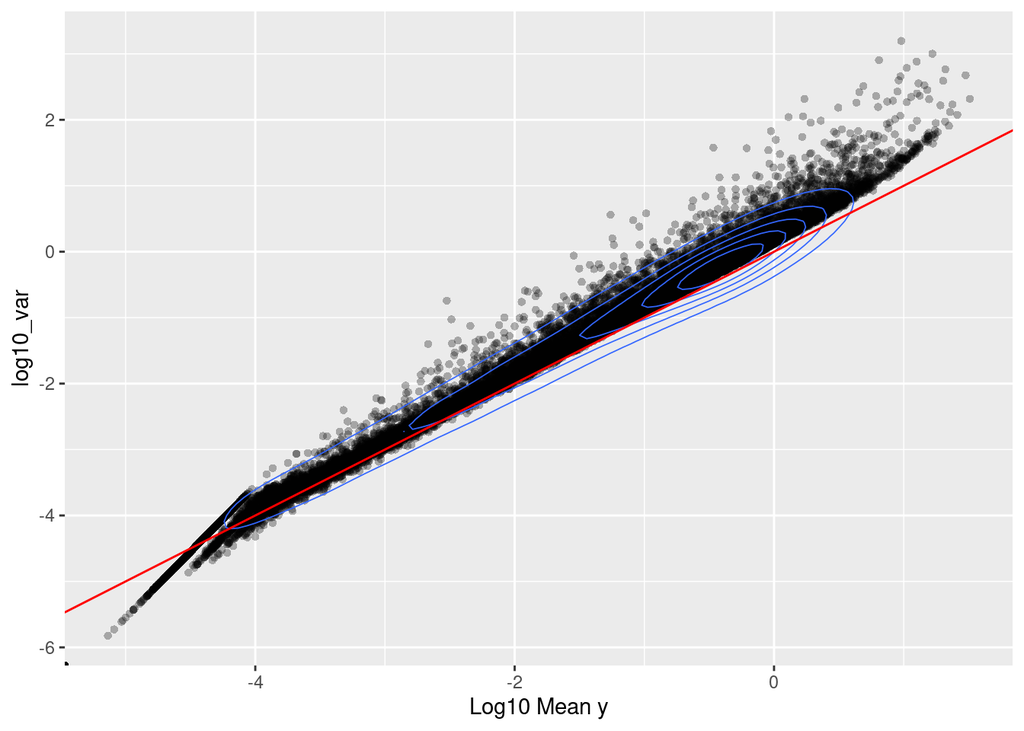

```r
gene_attr <- tibble::tibble(
  gene = rownames(gene_expression_mat),
  mean = Matrix::rowMeans(gene_expression_mat),
  detection_rate = Matrix::rowMeans(gene_expression_mat > 0),
  var = MatrixGenerics::rowVars(gene_expression_mat)) %>%
  mutate(log10_mean = log10(mean),
         log10_var = log10(var))

ggplot(gene_attr, aes(log10_mean, log10_var)) +
  geom_point(alpha = 0.3, shape = 16) +
  geom_density_2d(size = 0.3, bins = 6) +
  geom_abline(intercept = 0, slope = 1, color = "red") +
  labs(x = "Log10 Mean y", "Log10 Var y")
```

```r
gene_scores <- getMatrixFromProject(proj, useMatrix = "GeneScoreMatrix")

gene_scores_mat <- assays(gene_scores)[[1]]

min(gene_scores_mat)
```

```
## [1] 0
```

```r
max(gene_scores_mat)
```

```
## [1] 795.531
```

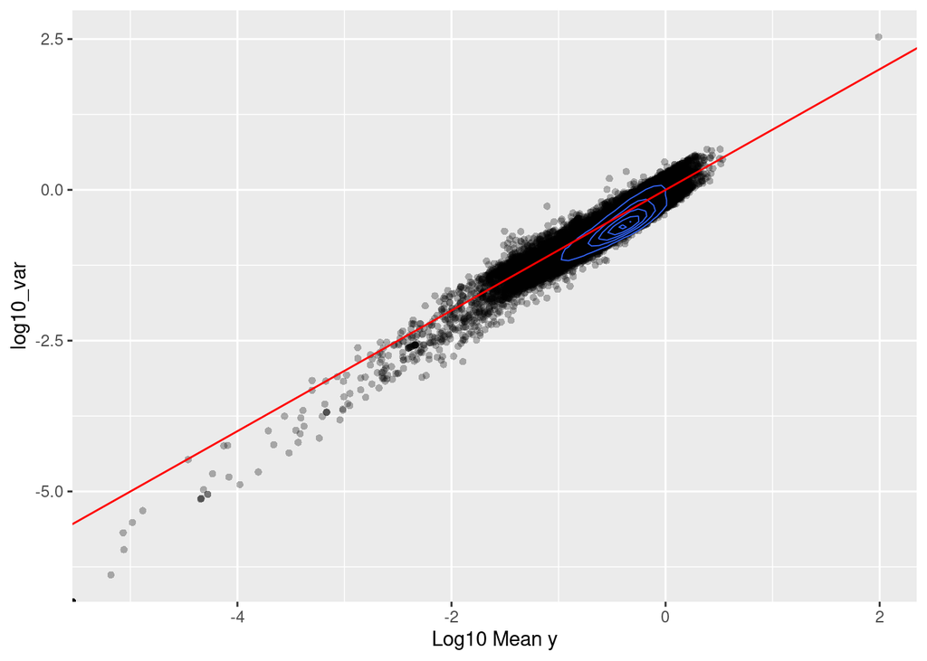

```r
gene_attr <- tibble::tibble(
  gene = rownames(gene_scores_mat),
  mean = Matrix::rowMeans(gene_scores_mat),
  detection_rate = Matrix::rowMeans(gene_scores_mat > 0),
  var = MatrixGenerics::rowVars(gene_scores_mat)) %>%
  mutate(log10_mean = log10(mean),
         log10_var = log10(var))

ggplot(gene_attr, aes(log10_mean, log10_var)) +
  geom_point(alpha = 0.3, shape = 16) +
  geom_density_2d(size = 0.3, bins = 6) +
  geom_abline(intercept = 0, slope = 1, color = "red") +
  labs(x = "Log10 Mean y", "Log10 Var y")
```